# R project

Pablo Martínez and Oriol Bustos

2024-03-15

# **R Project**

The aim of this project is to asses which are the variables that will have the greatest relevance to life expectancy and if it is possible to predict the evolution of life expectancy along the time. To answer these questions, public data from the Global Health Observatory (GHO) will be used. This dataset will contain 22 features, among which life expectancy will be present. The data is collected from 193 countries between 2000 and 2015.

# Index

### 1. Importing all the libraries

### 2. Load and clean-up the dataset

### 3. Exploring new tibbles based on preliminary research

### 4. Correlation variable analysis with Life Expectancy

### 5. Tackle the problem from a regression point of view

### 6. Conclusion

### 1.Importing all the libraries

```r
library(ggplot2)
library(tibble)
library(corrplot)
library(dplyr)
library(caret)
library(car)
```

### 2.Load and clean-up the dataset

The first thing that must be done is to import the dataset and transform this dataframe to a to a tibble format. This transformation is mainly done because tibble is a modern dataframe format which is compatible to the tidyverse.

```r
data<-read.csv("Life_Expectancy_Data.csv")
df_tib = as_tibble(data)
```

### *Cleaning up our data:*

A very common way to start this analysis is to explore how is the repartition of the missing values inside the dataframe. For that, it is necessary to count the number of NAN values in each column of the dataframe:

```r
# sum of NAN's in each column
NAN_counts <- colSums(is.na(df_tib))
# total sum of NAN's in the dataframe
NAN_tot <- sum(is.na(df_tib))
cat("Number of NAN values en each column:\n\n")
```

```
## Number of NAN values en each column:
```

```r
print(NAN_counts)
```

```
##                         Country                            Year
##                               0                               0
##                          Status                 Life.expectancy
##                               0                              10
##                 Adult.Mortality                   infant.deaths
##                              10                               0
##                         Alcohol          percentage.expenditure
##                             194                               0
##                     Hepatitis.B                         Measles
##                             553                               0
##                             BMI               under.five.deaths
##                              34                               0
##                           Polio               Total.expenditure
##                              19                             226
##                      Diphtheria                        HIV.AIDS
##                              19                               0
##                             GDP                      Population
##                             448                             652
##            thinness..1.19.years              thinness.5.9.years
##                              34                              34
## Income.composition.of.resources                       Schooling
##                             167                             163
```

```r
cat("\n\nThe total number of NAN values in the dataframe is:",NAN_tot, "\n")
```

```
##
##
## The total number of NAN values in the dataframe is: 2563
```

-The first thing that can be perceived after exploring the data is that there are plenty of NAN values in the years 2000 and 2015, so the rows related to these years should be removed from the dataframe to avoid missing values:

```r
# filter the dataframe for the years 2000 and 2015
rows_2000 <- df_tib%>%
  filter(Year == 2000)
rows_2015 <- df_tib%>%
  filter(Year == 2015)
# summing the nan values for these years
NAN_counts_2002 <- sum(is.na(rows_2000))
cat("Number of NAN values in the year 2000:", NAN_counts_2002, "\n")
```

```
## Number of NAN values in the year 2000: 204
```

```r
NAN_counts_2015 <- sum(is.na(rows_2015))
cat("Number of NAN values in the year 2015:", NAN_counts_2015, "\n")
```

```
## Number of NAN values in the year 2015: 463
```

```r
# assessing the percentage that represents in NAN's towards the whole dataset:
percent_NAN = ((NAN_counts_2002+NAN_counts_2015)/NAN_tot)*100
cat("The percentage of total NAN's that represent these 2 years is", percent_NAN,"\n")
```

```
## The percentage of total NAN's that represent these 2 years is 26.02419
```

As it is seen, years 2000 and 2015 contain more or less around 25% of the missing values of the whole dataset, so it is an interesting measure to remove these 2 years from the rows of the dataframe.

```r
new_df <- df_tib%>%
  filter(Year != 2000)%>%
  filter(Year != 2015)
NAN_new <- colSums(is.na(new_df))
cat("Number of NAN values en each column:\n\n")
```

```
## Number of NAN values en each column:
```

```r
print(NAN_new)
```

```
##                         Country                            Year
##                               0                               0
##                          Status                 Life.expectancy
##                               0                              10
##                 Adult.Mortality                   infant.deaths
##                              10                               0
##                         Alcohol          percentage.expenditure
##                              16                               0
##                     Hepatitis.B                         Measles
##                             446                               0
##                             BMI               under.five.deaths
##                              30                               0
##                           Polio               Total.expenditure
##                              16                              41
##                      Diphtheria                        HIV.AIDS
##                              16                               0
##                             GDP                      Population
##                             390                             571
##            thinness..1.19.years              thinness.5.9.years
##                              30                              30
## Income.composition.of.resources                       Schooling
##                             147                             143
```

For the remaining data what should be done is to remove the rows which still have missing values:

```r
# use filter to take only the values without NAN
clean_df <- na.omit(new_df)
NAN_clean <- sum(is.na(clean_df))
cat("The current number of NAN values is:", NAN_clean,".\n\n")
```

```
## The current number of NAN values is: 0 .
```

### *Then, we explore the datatype of all the variables in the dataframe:*

```r
glimpse(clean_df)
```

```
## Rows: 1,586
## Columns: 22
## $ Country                         <chr> "Afghanistan", "Afghanistan", "Afghani…
## $ Year                            <int> 2014, 2013, 2012, 2011, 2010, 2009, 20…
## $ Status                          <chr> "Developing", "Developing", "Developin…
## $ Life.expectancy                 <dbl> 59.9, 59.9, 59.5, 59.2, 58.8, 58.6, 58…
## $ Adult.Mortality                 <int> 271, 268, 272, 275, 279, 281, 287, 295…
## $ infant.deaths                   <int> 64, 66, 69, 71, 74, 77, 80, 82, 84, 85…
## $ Alcohol                         <dbl> 0.01, 0.01, 0.01, 0.01, 0.01, 0.01, 0.…
## $ percentage.expenditure          <dbl> 73.523582, 73.219243, 78.184215, 7.097…
## $ Hepatitis.B                     <int> 62, 64, 67, 68, 66, 63, 64, 63, 64, 66…
## $ Measles                         <int> 492, 430, 2787, 3013, 1989, 2861, 1599…
## $ BMI                             <dbl> 18.6, 18.1, 17.6, 17.2, 16.7, 16.2, 15…
## $ under.five.deaths               <int> 86, 89, 93, 97, 102, 106, 110, 113, 11…
## $ Polio                           <int> 58, 62, 67, 68, 66, 63, 64, 63, 58, 58…
## $ Total.expenditure               <dbl> 8.18, 8.13, 8.52, 7.87, 9.20, 9.42, 8.…
## $ Diphtheria                      <int> 62, 64, 67, 68, 66, 63, 64, 63, 58, 58…
## $ HIV.AIDS                        <dbl> 0.1, 0.1, 0.1, 0.1, 0.1, 0.1, 0.1, 0.1…
## $ GDP                             <dbl> 612.69651, 631.74498, 669.95900, 63.53…
## $ Population                      <dbl> 327582, 31731688, 3696958, 2978599, 28…
## $ thinness..1.19.years            <dbl> 17.5, 17.7, 17.9, 18.2, 18.4, 18.6, 18…
## $ thinness.5.9.years              <dbl> 17.5, 17.7, 18.0, 18.2, 18.4, 18.7, 18…
## $ Income.composition.of.resources <dbl> 0.476, 0.470, 0.463, 0.454, 0.448, 0.4…
## $ Schooling                       <dbl> 10.0, 9.9, 9.8, 9.5, 9.2, 8.9, 8.7, 8.…
```

### *Computing the zero values present in the dataframe:*

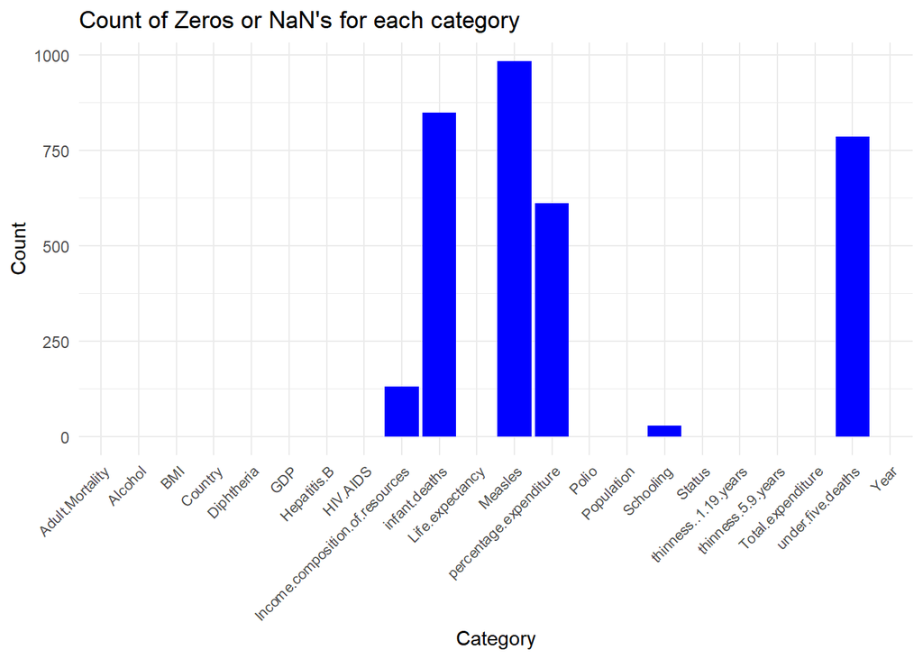

```r
count_zeros <- colSums(df_tib == 0, na.rm = TRUE)

count_zeros_df <- data.frame(category = names(count_zeros), CountOfZeros = count_zeros)


ggplot(count_zeros_df, aes(x = category, y = CountOfZeros)) +
  geom_bar(stat = "identity", fill = "blue") +
  labs(title = "Count of Zeros or NaN's for each category", x = "Category", y = "Count") +
  theme_minimal() +
  theme(axis.text.x = element_text(angle = 45, hjust = 1, vjust = 1, size = 8))
```

## Exploring new tibbles based on preliminary research

### *Exploring the evolution of life expectancy along the years:*

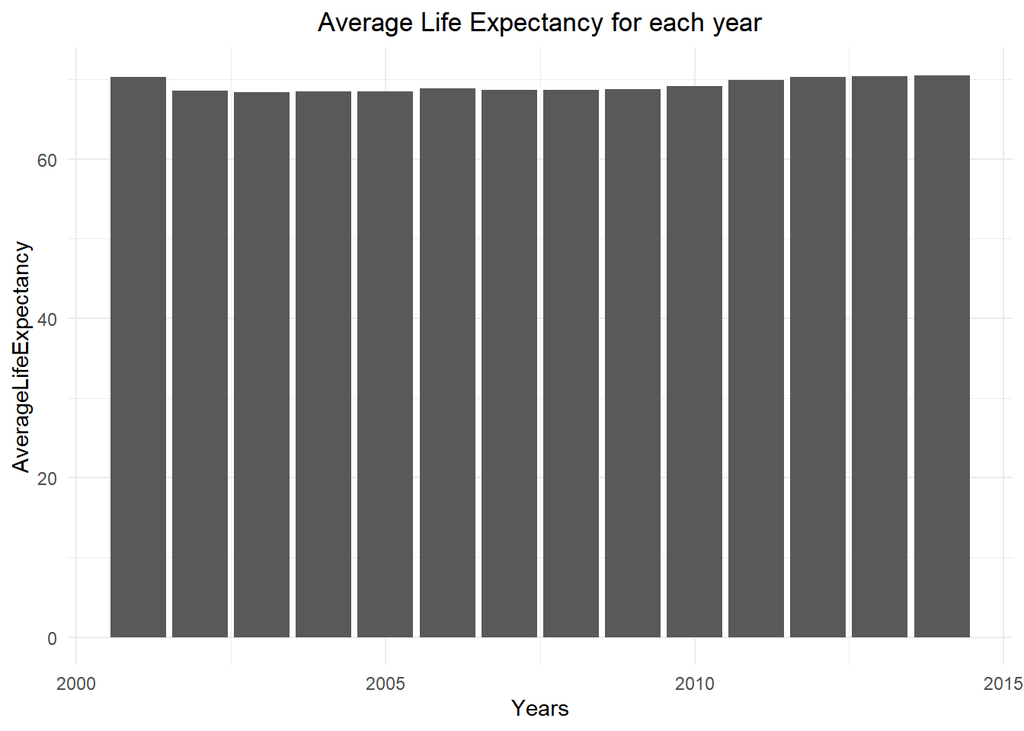

```r
subset_averageLifeExpectancy <- clean_df %>%
  group_by(Year)%>%
  summarise(AverageLifeExpectancy = mean(Life.expectancy, na.rm = TRUE))

ggplot(subset_averageLifeExpectancy, aes(x=Year, y= AverageLifeExpectancy))+geom_col()+expand_limits(y=0)+labs(title = "Average Life Expectancy for each year", x="Years")+theme_minimal()+theme(plot.title = element_text(hjust=0.5))
```

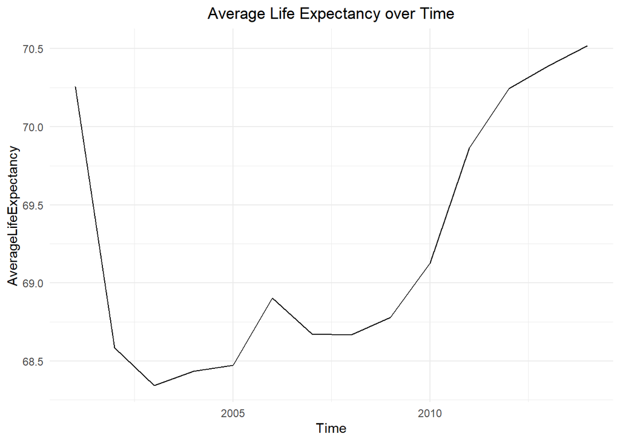

```r
ggplot(subset_averageLifeExpectancy, aes(x=Year, y= AverageLifeExpectancy))+geom_line()+labs(title = "Average Life Expectancy over Time", x = "Time")+theme_minimal()+theme(plot.title = element_text(hjust=0.5))
```

```r
cat("\n")
```

### *Exploring the evolution of life expectancy for different continents:*

In order to carry on this analysis, the countries should be grouped in the continents they belong to. For that, we asked ChatGPT to create vectors of the 5 main continents and store the names of the different countries.

```r
Africa <- c(
  "Algeria", "Angola", "Benin", "Botswana", "Burkina Faso", "Burundi",
  "Cape Verde", "Cameroon", "Cabo Verde","Chad", "Comoros", "Democratic Republic of the Congo",
  "Djibouti", "Egypt", "Equatorial Guinea", "Eritrea", "Eswatini", "Ethiopia",
  "Gabon", "Gambia", "Ghana", "Guinea", "Guinea-Bissau", "Ivory Coast",
  "Kenya", "Lesotho", "Liberia", "Libya", "Madagascar", "Malawi", "Mali",
  "Mauritania", "Mauritius", "Morocco", "Mozambique", "Namibia", "Niger",
  "Nigeria", "Rwanda", "Sao Tome and Principe", "Senegal", "Seychelles",
  "Sierra Leone", "Somalia", "South Africa", "South Sudan", "Sudan", "Tanzania",
  "Togo", "Tunisia", "Uganda", "Zambia", "Zimbabwe","Central African Republic", "Swaziland","Côte d'Ivoire", "Congo", "United Republic of Tanzania")
Europe <- c(
  "Albania", "Andorra", "Armenia", "Austria", "Azerbaijan",
  "Belarus", "Belgium", "Bosnia and Herzegovina", "Bulgaria",
  "Croatia", "Cyprus", "Czech Republic","Denmark","Estonia","Finland", "France","Georgia", "Germany", "Greece","Hungary","Iceland", "Ireland", "Italy","Kazakhstan", "Kosovo","Latvia", "Liechtenstein", "Lithuania", "Luxembourg","Malta", "Moldova", "Monaco", "Montenegro",  "Netherlands", "North Macedonia", "Norway","Poland", "Portugal","Romania", "Russia", "San Marino", "Serbia", "Slovakia", "Slovenia", "Spain", "Sweden","Switzerland","Turkey","Ukraine", "United Kingdom", "Vatican City","Russian Federation", "Czechia", "Republic of Moldova", "The former Yugoslav republic of Macedonia", "United Kingdom of Great Britain and Northern Ireland")

Asia <- c(
  "Afghanistan", "Armenia", "Azerbaijan", "Bahrain", "Bangladesh", "Bhutan",
  "Brunei", "Cambodia", "China", "Cyprus",
  "Georgia", "India", "Indonesia", "Iran", "Iraq", "Israel",
  "Japan", "Jordan",
  "Kazakhstan", "Kuwait", "Kyrgyzstan",
  "Laos", "Lebanon",
  "Malaysia", "Maldives", "Mongolia", "Myanmar",
  "Nepal", "North Korea",
  "Oman",
  "Pakistan", "Palestine", "Philippines",
  "Qatar",
  "Russia",
  "Saudi Arabia", "Singapore", "South Korea", "Sri Lanka", "Syria",
  "Taiwan", "Tajikistan", "Thailand", "Timor-Leste", "Turkey", "Turkmenistan",
  "United Arab Emirates", "Uzbekistan",
  "Vietnam",
  "Yemen","Syrian Arab Republic","Brunei Darussalam", "Democratic People's Republic of Korea", "Iran (Islamic Republic of)", "Lao People's Democratic Republic", "Republic of Korea", "Viet Nam")

  Oceania <- c(
  "Australia", "Fiji",
  "Kiribati",
  "Marshall Islands", "Micronesia",
  "Nauru", "New Zealand",
  "Palau", "Papua New Guinea",
  "Samoa", "Solomon Islands",
  "Tonga", "Tuvalu",
  "Vanuatu", "Cook Islands", "Micronesia (Federated States of)", "Niue")

  America <- c(
    "Antigua and Barbuda", "Argentina", "Bahamas", "Barbados", "Belize", "Bolivia",
    "Brazil", "Canada", "Chile", "Colombia", "Costa Rica", "Cuba", "Dominica",
    "Dominican Republic", "Ecuador", "El Salvador", "Grenada", "Guatemala", "Guyana",
    "Haiti", "Honduras", "Jamaica", "Mexico", "Nicaragua", "Panama", "Paraguay",
    "Peru", "Saint Kitts and Nevis", "Saint Lucia", "Saint Vincent and the Grenadines",
    "Suriname", "Trinidad and Tobago", "United States", "Uruguay", "Venezuela","Bolivia (Plurinational State of)", "United States of America", "Venezuela (Bolivarian Republic of)")
```

Once the vectors are created, the idea is to create a subset using tidyverse that implements a new column called “Continent” where each country is associated to its continent.

```r
  subset_continents <- clean_df %>%
mutate(Continent = case_when(
    Country %in% Africa ~ "Africa",
    Country %in% Europe ~ "Europe",
    Country %in% Asia ~ "Asia",
    Country %in% America ~ "America",
    Country %in% Oceania ~ "Oceania",
    TRUE ~ "Other")) %>%
  group_by(Continent)

# for the countries that didn't appear, after printing them we added them to the previous vectors depending on the continent they were belonging to
  countries_classified_other <- subset_continents %>%
  filter(Continent == "Other") %>%
  distinct(Country) %>%
  pull(Country)

# print(countries_classified_other)
```

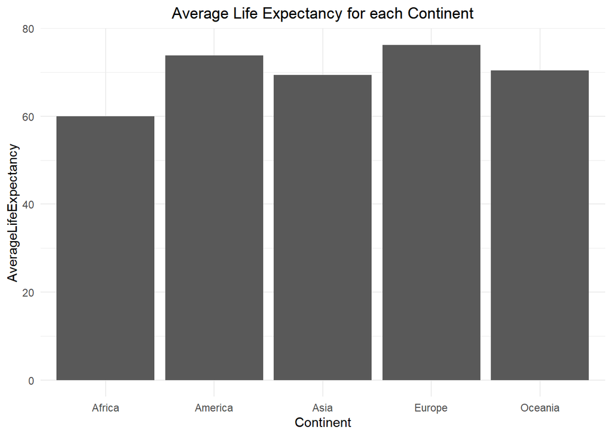

```r
subset_continents <- clean_df %>%
mutate(Continent = case_when(
    Country %in% Africa ~ "Africa",
    Country %in% Europe ~ "Europe",
    Country %in% Asia ~ "Asia",
    Country %in% America ~ "America",
    Country %in% Oceania ~ "Oceania",
    TRUE ~ "Other")) %>%
  group_by(Continent)%>%
  summarise(AverageLifeExpectancy = mean(Life.expectancy, na.rm = TRUE))

ggplot(subset_continents, aes(x=Continent, y= AverageLifeExpectancy))+geom_col()+expand_limits(y=0)+labs(title = "Average Life Expectancy for each Continent", x = "Continent")+theme_minimal()+theme(plot.title = element_text(hjust=0.5))
```

```r
cat("\n")
```

As we can see, there is a big difference in terms of life expectancy between the highest and the lowest values, which correspond respectively to Europe and Africa. This shows that the continent should be a variable taken into account to explain the life expectancy of population around the world.

### *Exploring the evolution of life expectancy as a function of countries’ level of development:*

As in the previous section, we asked ChatGPT to create again some vectors classifying the countries towards their development status, as 1st, 2nd or 3rd world countries. Then, a subset for the dataset will be created adding as a new variable the development status of the country

```r
first_world_countries <- c(
  "Australia", "Andorra","Austria", "Belgium", "Canada", "Denmark",
  "Finland", "France", "Germany", "Greece", "Iceland",
  "Ireland", "Italy", "Luxembourg", "Malta", "Netherlands",
  "New Zealand", "Norway", "Portugal", "Spain", "Sweden",
  "Switzerland", "United Kingdom", "United States","Estonia", "Poland", "Czech Republic","South Korea", "Japan","Monaco","San Marino", "United Kingdom of Great Britain and Northern Ireland")

second_world_countries <- c(
  "China","Brasil","Belarus", "Bosnia and Herzegovina", "Bulgaria",
  "Croatia", "Georgia", "Hungary",
  "Latvia", "Lithuania", "Moldova",
  "Montenegro", "Romania", "Russia", "Serbia",
  "Slovakia", "Slovenia", "Ukraine", "Nigeria", "Chile", "Costa Rica","Russian Federation","Czechia", "Republic of Moldova", "The former Yugoslav republic of Macedonia")

third_world_countries <- c("Albania",
  setdiff(Africa, c("Nigeria")),
  setdiff(Oceania, c("Australia", "New Zealand")),
  setdiff(America, c("Canada", "United States", "Chile", "Costa Rica","Brasil")),
  setdiff(Asia, c("Japan", "South Korea", "China"))
)

add_developed <- clean_df %>%
mutate(Development = case_when(
    Country %in% first_world_countries ~ "First",
    Country %in% second_world_countries ~ "Second",
    Country %in% third_world_countries ~ "Third",
    TRUE ~ "Other")) %>%
  group_by(Development)

# for the countries that didn't appear, after printing them we added them to the previous vectors depending on the status they were belonging to
countries_classified_other <- add_developed %>%
  filter(Development == "Other") %>%
  distinct(Country) %>%
  pull(Country)

# print(countries_classified_other)
```

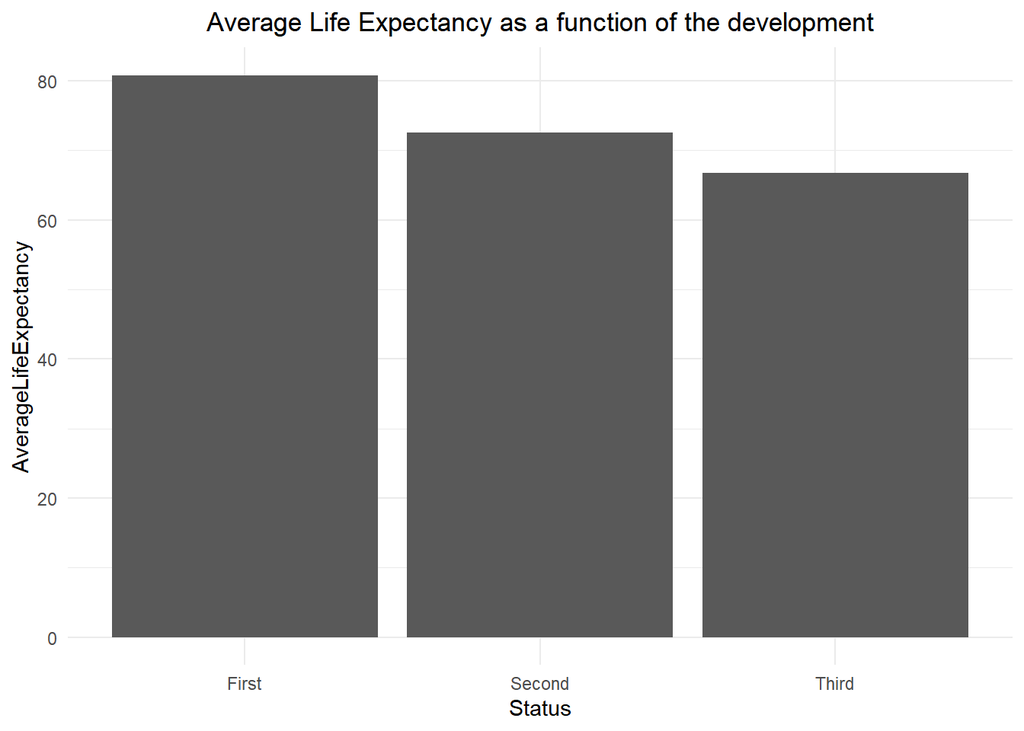

```r
subset_developed <- clean_df %>%
mutate(Development = case_when(
    Country %in% first_world_countries ~ "First",
    Country %in% second_world_countries ~ "Second",
    Country %in% third_world_countries ~ "Third",
    TRUE ~ "Other")) %>%
  group_by(Development)%>%
  summarise(AverageLifeExpectancy = mean(Life.expectancy, na.rm = TRUE))

ggplot(subset_developed, aes(x=Development, y= AverageLifeExpectancy))+geom_col()+expand_limits(y=0)+labs(title = "Average Life Expectancy as a function of the development", x = "Status")+theme_minimal()+theme(plot.title = element_text(hjust=0.5))
```

```r
cat("\n")
```

### *Exploring the evolution of life expectancy for different variables:*

Some other interesting variables that can show patterns towards the Life expectancy evolution are GDP (Gross Domestic Product), the predefined status in the dataset or the BMI (Body Mass Index). By evaluating these relationships, some graphically visual conclusions can be extracted directly.

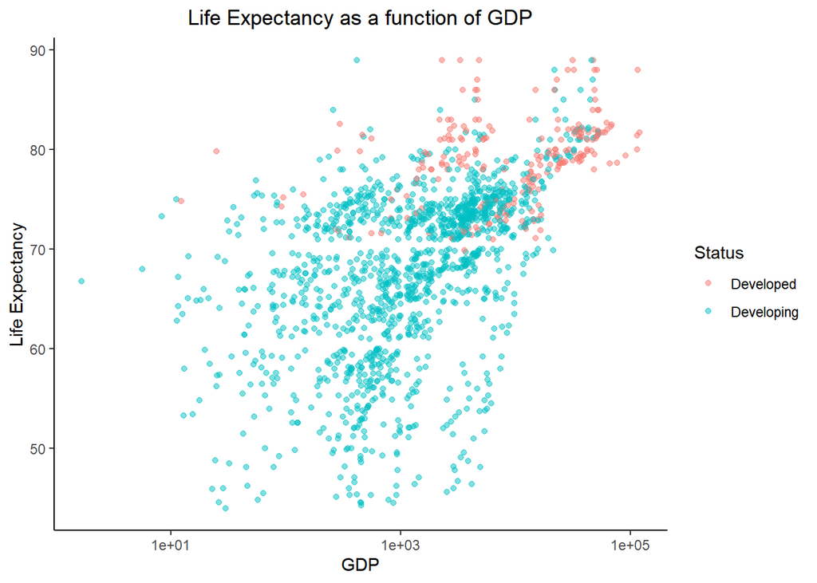

```r
ggplot(clean_df, aes(x = GDP, y = Life.expectancy, color = Status)) +
  geom_point(alpha = 0.5) + theme_classic()+ scale_x_log10()+theme(plot.title = element_text(hjust=0.5))+
  labs(title = "Life Expectancy as a function of GDP",
       x = "GDP",
       y = "Life Expectancy")
```

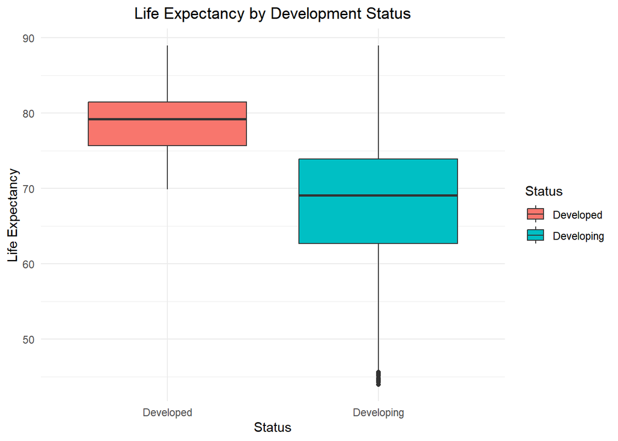

```r
ggplot(clean_df, aes(x = Status, y = Life.expectancy, fill = Status)) +
  geom_boxplot() + theme_minimal() + theme(plot.title = element_text(hjust=0.5))+
  labs(title = "Life Expectancy by Development Status",
       x = "Status",
       y = "Life Expectancy")
```

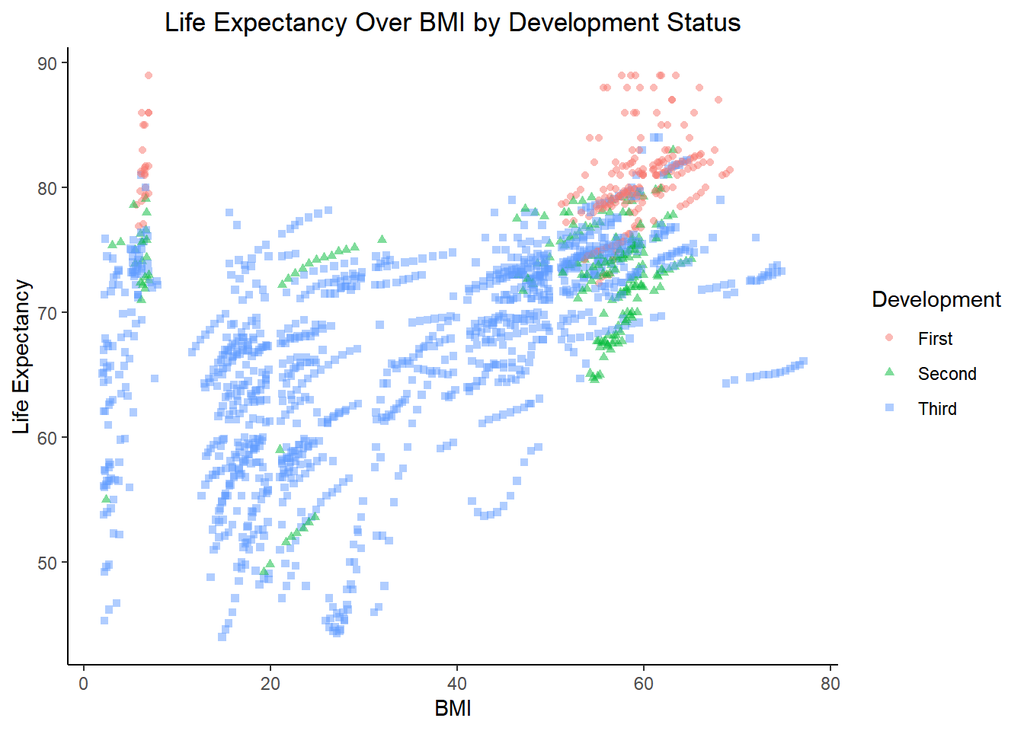

```r
ggplot(add_developed, aes(x = BMI, y = Life.expectancy, color = Development, shape = Development)) +
  geom_point(alpha = 0.5) + theme_classic() + theme(plot.title = element_text(hjust = 0.5))+
  labs(title = "Life Expectancy Over BMI by Development Status",
       x = "BMI",
       y = "Life Expectancy")
```

The results observed in the graphs reflect the following conclusions:

- In Developed countries with high GDP’s the life expectancy increases notably compared to the low GDP developing countries
- Life expectancy in countries of Developed status is significantly higher than in countries developing.
- BMI increases in countries with a higher level of development, and so does the life expectancy.

## Correlation variable analysis with Life Expectancy

Now let’s explore which are the variables that are mostly correlated to the Life Expectancy in general:

To run the correlation, all the dataframe values must be ‘numeric’ type, so we transform the int values to numeric and remove the character variables to do this analysis, we will lose information about the country and the status, but the correlation test can’t be performed otherwise.

```r
correlation_df<-clean_df
correlation_df$Year <- as.numeric(correlation_df$Year)
correlation_df$Adult.Mortality <- as.numeric(correlation_df$Adult.Mortality )
correlation_df$infant.deaths <- as.numeric(correlation_df$infant.deaths)
correlation_df$Hepatitis.B <- as.numeric(correlation_df$Hepatitis.B)
correlation_df$Measles <- as.numeric(correlation_df$Measles)
correlation_df$under.five.deaths <- as.numeric(correlation_df$under.five.deaths)
correlation_df$Polio <- as.numeric(correlation_df$Polio)
correlation_df$Diphtheria <- as.numeric(correlation_df$Diphtheria)
correlation_df<-correlation_df[ ,!(names(correlation_df) %in% c("Country", "Status"))]
```

Once this is done, the correlation matrix is performed for all the variables in the dataframe.

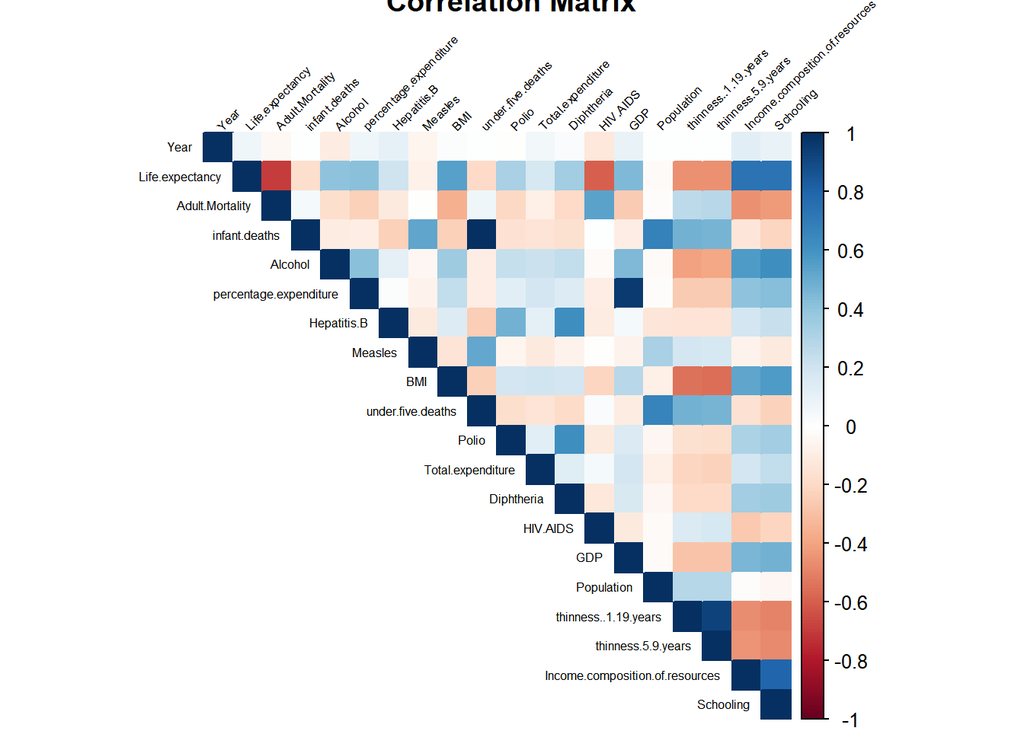

```r
correlation_matrix<- cor(correlation_df)
corrplot(correlation_matrix,title = "Correlation Matrix", method="color", type="upper",
         tl.col = "black", tl.srt=45, tl.cex=0.5)
```

```r
cat("\n")
```

Among all these values, let’s infer in which variables are more correlated with the Life Expectancy by taking only the 5 highest values in the correlation matrix, discarding the correlation of Life expectancy with itself obviously:

```r
# selecting the correlation between life expectancy and the other variables
correlation_Life_Exp  <- correlation_matrix["Life.expectancy", ]
# sort the value in a decreasing order:
ordered_vals <- sort(correlation_Life_Exp, decreasing = TRUE)
# Printing all the correlations:
print(ordered_vals)
```

```
##                 Life.expectancy Income.composition.of.resources
##                      1.00000000                      0.73639739
##                       Schooling                             BMI
##                      0.73160592                      0.54549623
##                             GDP          percentage.expenditure
##                      0.44470596                      0.41265602
##                         Alcohol                      Diphtheria
##                      0.40232996                      0.34909519
##                           Polio                     Hepatitis.B
##                      0.32904325                      0.20703834
##               Total.expenditure                            Year
##                      0.17912500                      0.06337749
##                      Population                         Measles
##                     -0.02221105                     -0.07049901
##                   infant.deaths               under.five.deaths
##                     -0.17075977                     -0.19399173
##              thinness.5.9.years            thinness..1.19.years
##                     -0.45497203                     -0.45571226
##                        HIV.AIDS                 Adult.Mortality
##                     -0.59212659                     -0.69701570
```

After looking at the correlations, the top5 significant ones are:

```r
highest_cor <- c(ordered_vals[2], ordered_vals[3], tail(ordered_vals, n=1), ordered_vals[length(ordered_vals)-1], ordered_vals[4])
print(highest_cor)
```

```
## Income.composition.of.resources                       Schooling
##                       0.7363974                       0.7316059
##                 Adult.Mortality                        HIV.AIDS
##                      -0.6970157                      -0.5921266
##                             BMI
##                       0.5454962
```

## Tackle the problem from a regression point of view

### *Exploring the distribution of data in variables:*

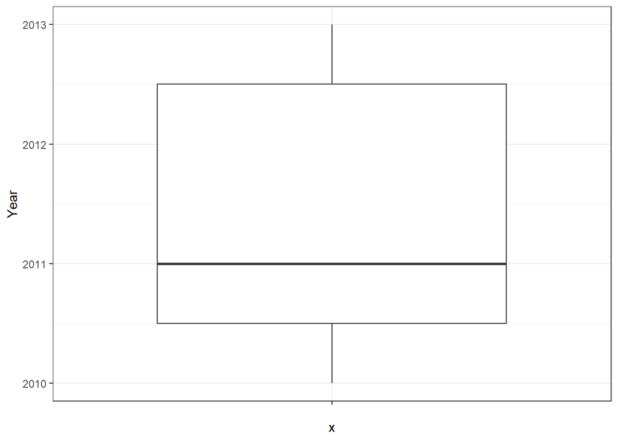

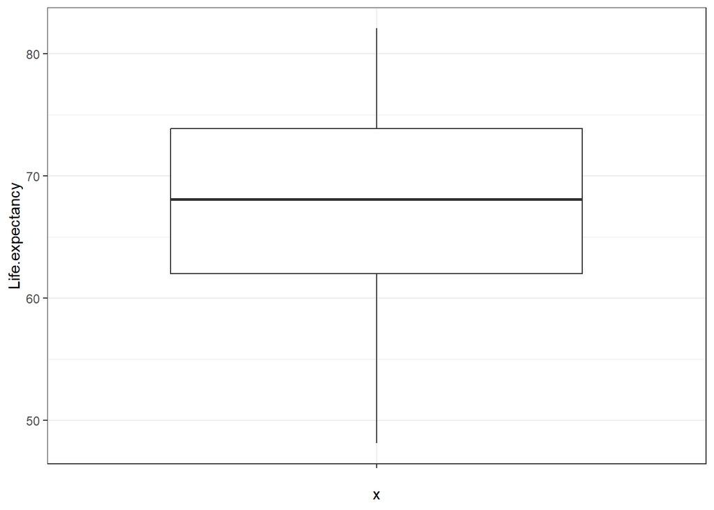

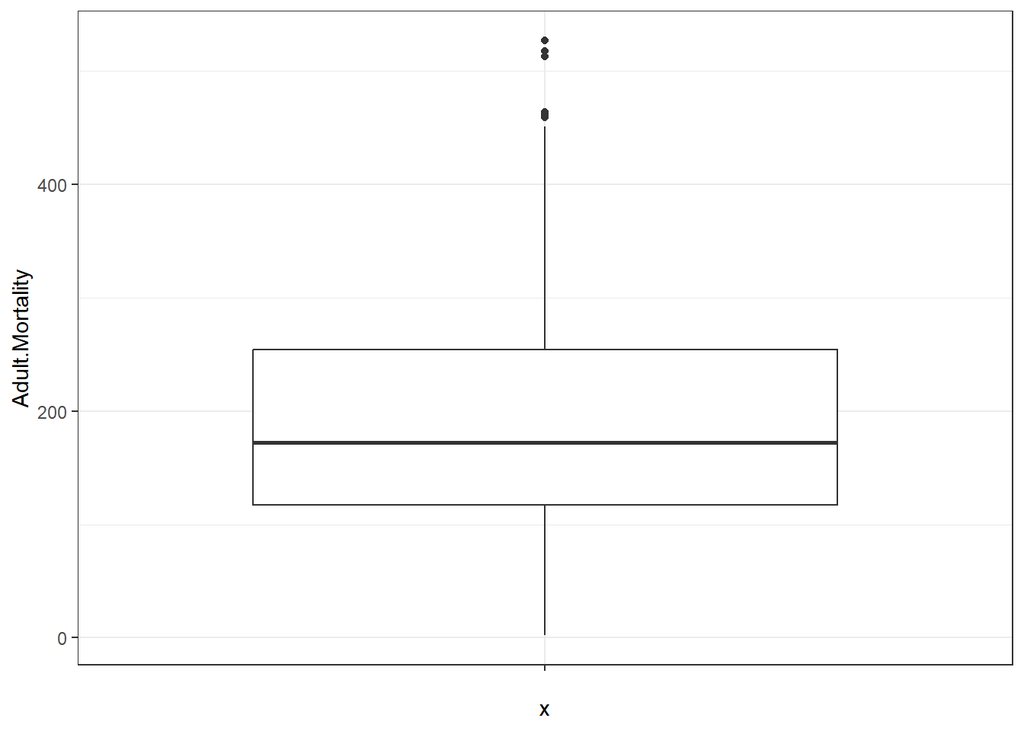

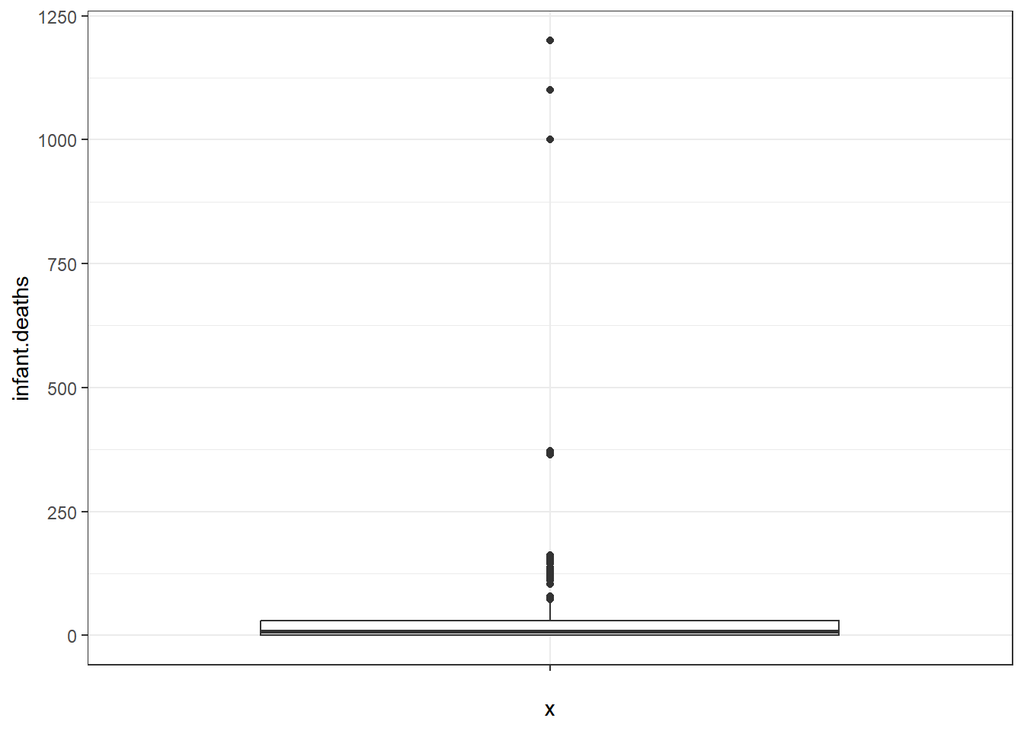

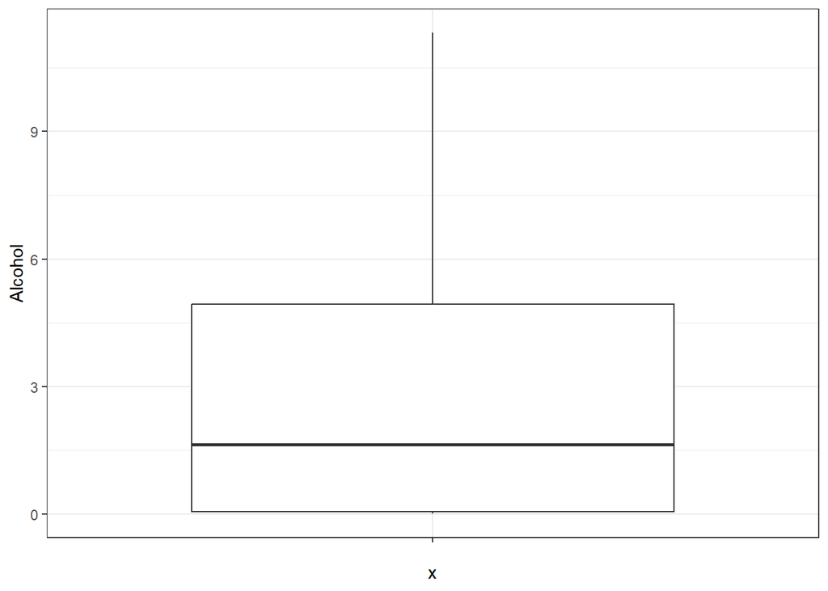

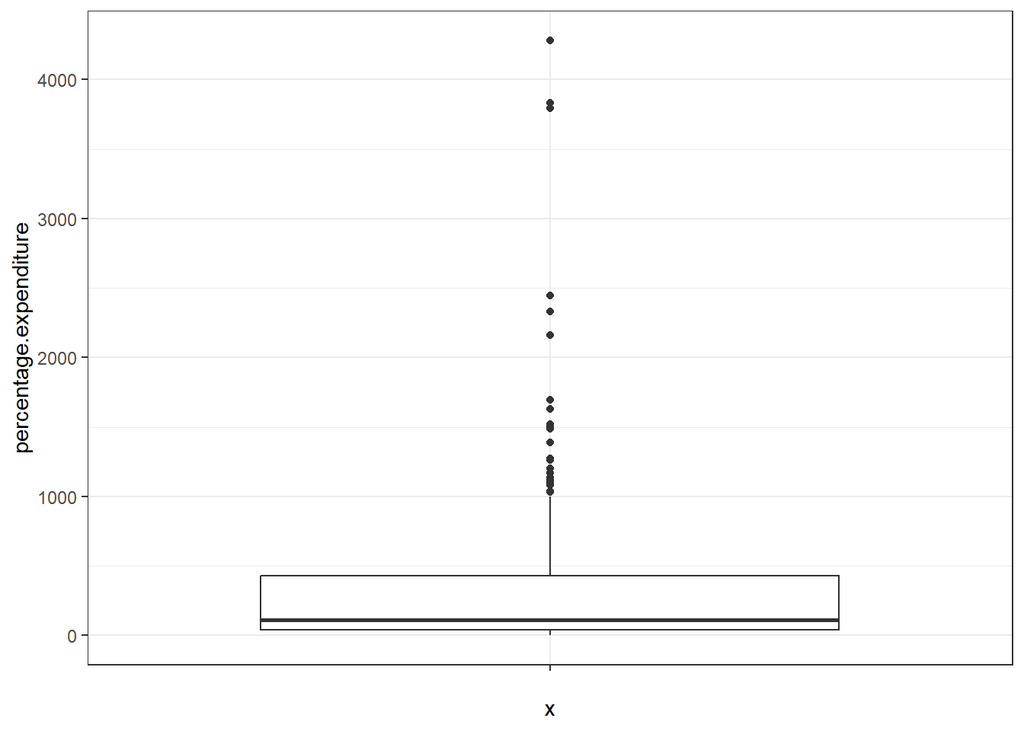

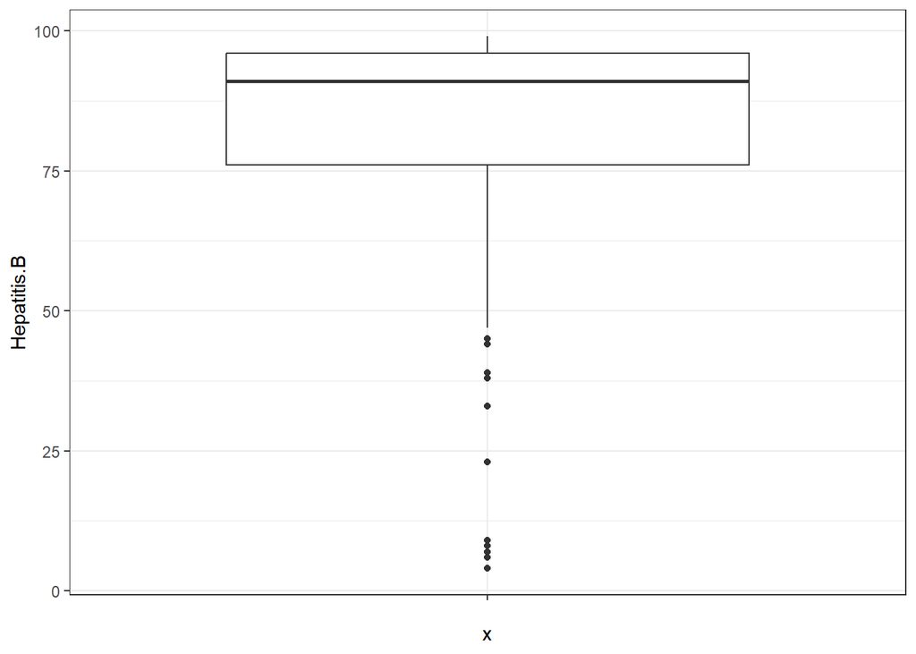

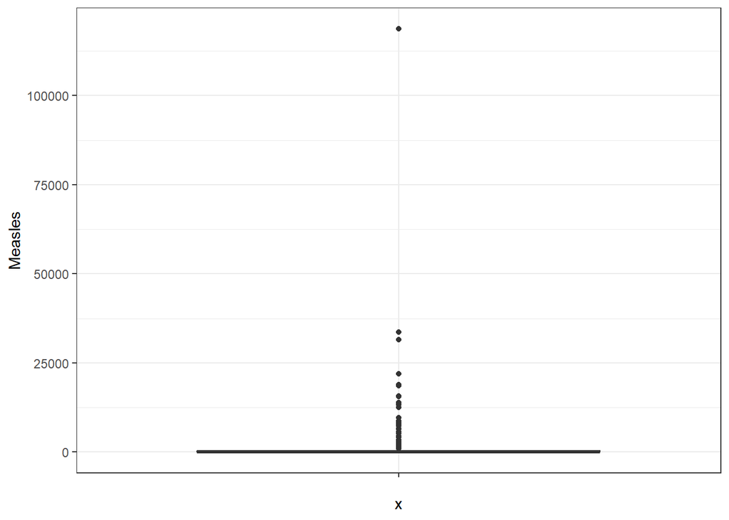

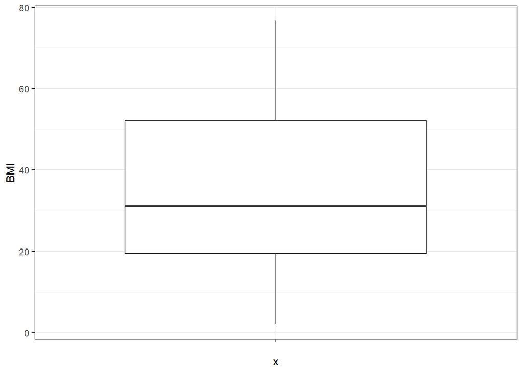

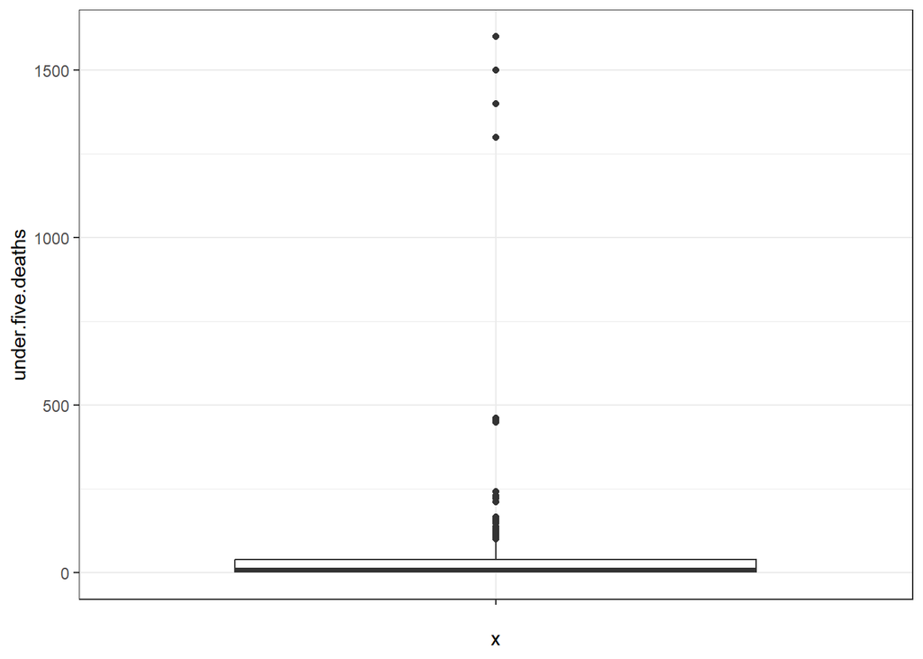

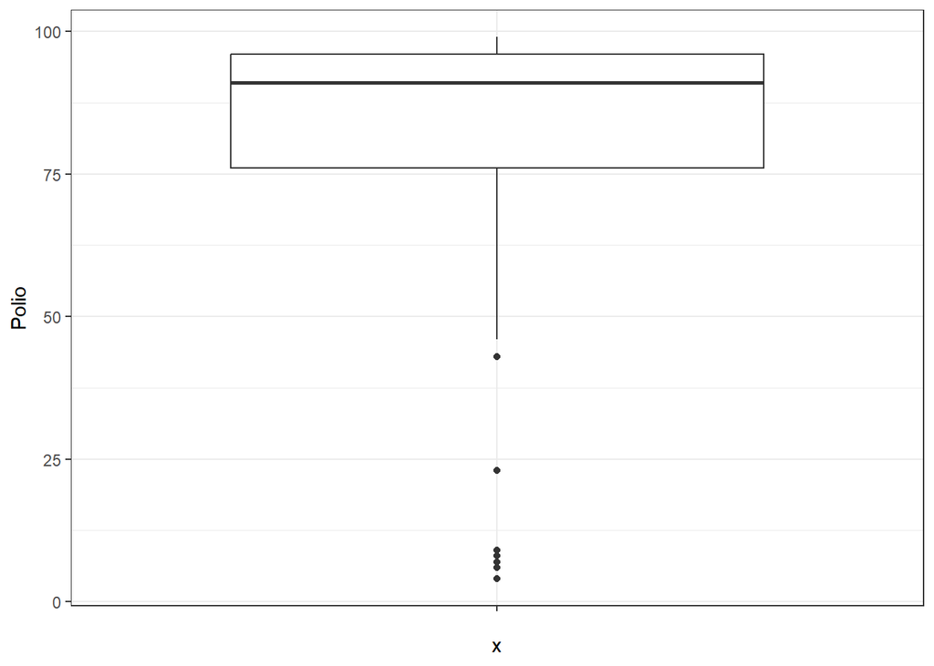

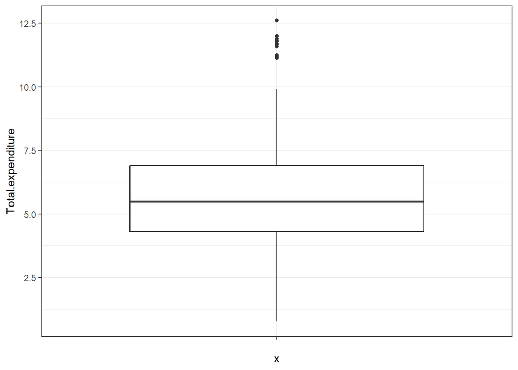

[9 more figures not shown]

```r
subset_developing_1013 <- add_developed %>%
  filter(Development == "Third") %>%
  filter(Year >= 2010 & Year<= 2013)

subset_developing_1013$Year <- as.numeric(subset_developing_1013$Year)
subset_developing_1013$Adult.Mortality <- as.numeric(subset_developing_1013$Adult.Mortality )
subset_developing_1013$infant.deaths <- as.numeric(subset_developing_1013$infant.deaths)
subset_developing_1013$Hepatitis.B <- as.numeric(subset_developing_1013$Hepatitis.B)
subset_developing_1013$Measles <- as.numeric(subset_developing_1013$Measles)
subset_developing_1013$under.five.deaths <- as.numeric(subset_developing_1013$under.five.deaths)
subset_developing_1013$Polio <- as.numeric(subset_developing_1013$Polio)
subset_developing_1013$Diphtheria <- as.numeric(subset_developing_1013$Diphtheria)
subset_developing_1013<-subset_developing_1013[ ,!(names(subset_developing_1013) %in% c("Country", "Status"))]

for (i in seq_along(subset_developing_1013)){
  plot <- ggplot(subset_developing_1013, aes(x = "", y = subset_developing_1013[[i]])) +
  geom_boxplot() + theme_bw() +
  labs(y = as.character(names(subset_developing_1013)[[i]]))

  print(plot)
}
```

So now from the information provided by the correlation matrix and the boxplots, some conclusions about which variables should be considered as relevant to predict life expectancy can be extracted. Concerning the 5 highest correlations, the ones showing the least outliers are Income composition of ressources and BMI. Other usable variables could be Alcohol, percentage expenditures, Polio, Diptheria, GDP, thinness..1.19.years or thinness.5.9.years.

### *Perform predictions from the cleaned dataframe:*

As a first trial to try to predict Life expectancy, the whole cleaned-up dataframe can be used.

```r
# Converting integers to numeric and removing character variables
clean_df<-clean_df
clean_df$Year <- as.numeric(correlation_df$Year)
clean_df$Adult.Mortality <- as.numeric(correlation_df$Adult.Mortality )
clean_df$infant.deaths <- as.numeric(correlation_df$infant.deaths)
clean_df$Hepatitis.B <- as.numeric(correlation_df$Hepatitis.B)
clean_df$Measles <- as.numeric(correlation_df$Measles)
clean_df$under.five.deaths <- as.numeric(correlation_df$under.five.deaths)
clean_df$Polio <- as.numeric(correlation_df$Polio)
clean_df$Diphtheria <- as.numeric(correlation_df$Diphtheria)
clean_df<-correlation_df[ ,!(names(correlation_df) %in% c("Country", "Status"))]

set.seed(666)
# taking the 70% for training
train_indices <- sample(1:nrow(clean_df), 0.7 * nrow(clean_df))

# splitting into train and test
train <- clean_df[train_indices, ]
test <- clean_df[-train_indices, ]

# define the model and the variables used in it
model <- lm(Life.expectancy ~., data = train) # ~ . for all variables
summary(model)
```

```
##
## Call:
## lm(formula = Life.expectancy ~ ., data = train)
##
## Residuals:
##      Min       1Q   Median       3Q      Max
## -11.0620  -2.0367   0.0021   2.1504  12.8028
##
## Coefficients:
##                                   Estimate Std. Error t value Pr(>|t|)
## (Intercept)                      3.729e+02  5.916e+01   6.303 4.23e-10 ***
## Year                            -1.601e-01  2.952e-02  -5.423 7.23e-08 ***
## Adult.Mortality                 -1.535e-02  1.153e-03 -13.313  < 2e-16 ***
## infant.deaths                    8.665e-02  1.279e-02   6.775 2.03e-11 ***
## Alcohol                         -1.189e-01  3.784e-02  -3.143  0.00172 **
## percentage.expenditure           3.383e-04  1.957e-04   1.729  0.08415 .
## Hepatitis.B                     -4.041e-04  5.765e-03  -0.070  0.94413
## Measles                         -9.840e-06  1.275e-05  -0.772  0.44052
## BMI                              3.668e-02  7.386e-03   4.966 7.94e-07 ***
## under.five.deaths               -6.556e-02  9.362e-03  -7.003 4.39e-12 ***
## Polio                            2.204e-03  6.426e-03   0.343  0.73166
## Total.expenditure                1.591e-01  5.005e-02   3.178  0.00152 **
## Diphtheria                       1.470e-02  7.459e-03   1.971  0.04901 *
## HIV.AIDS                        -4.973e-01  2.278e-02 -21.829  < 2e-16 ***
## GDP                              2.718e-05  3.041e-05   0.894  0.37162
## Population                      -1.328e-10  1.890e-09  -0.070  0.94401
## thinness..1.19.years             1.592e-02  5.931e-02   0.268  0.78839
## thinness.5.9.years              -3.929e-02  5.836e-02  -0.673  0.50100
## Income.composition.of.resources  1.132e+01  1.029e+00  11.005  < 2e-16 ***
## Schooling                        8.996e-01  7.229e-02  12.444  < 2e-16 ***
## ---
## Signif. codes:  0 '***' 0.001 '**' 0.01 '*' 0.05 '.' 0.1 ' ' 1
##
## Residual standard error: 3.521 on 1090 degrees of freedom
## Multiple R-squared:  0.8434, Adjusted R-squared:  0.8407
## F-statistic: 309.1 on 19 and 1090 DF,  p-value: < 2.2e-16
```

```r
# make the predictions
predicted <- predict (model, newdata = test)

# compare the values in the predictions tp the stored in the test set
mse <- mean((predicted-test$Life.expectancy)^2)
cat("The mean-squared error is: ", mse, ".\n")
```

```
## The mean-squared error is:  13.75805 .
```

```r
rmse <- RMSE(predicted, test$Life.expectancy)
cat("The Root mean-squared error is: ", rmse, ".\n")
```

```
## The Root mean-squared error is:  3.709185 .
```

```r
# Converting integers to numeric and removing character variable
subset_developing_1013$Year <- as.numeric(subset_developing_1013$Year)
subset_developing_1013$Adult.Mortality <- as.numeric(subset_developing_1013$Adult.Mortality )
subset_developing_1013$infant.deaths <- as.numeric(subset_developing_1013$infant.deaths)
subset_developing_1013$Hepatitis.B <- as.numeric(subset_developing_1013$Hepatitis.B)
subset_developing_1013$Measles <- as.numeric(subset_developing_1013$Measles)
subset_developing_1013$under.five.deaths <- as.numeric(subset_developing_1013$under.five.deaths)
subset_developing_1013$Polio <- as.numeric(subset_developing_1013$Polio)
subset_developing_1013$Diphtheria <- as.numeric(subset_developing_1013$Diphtheria)
subset_developing_1013<-subset_developing_1013[ ,!(names(subset_developing_1013) %in% c("Country", "Status", "Development"))]

set.seed(666)
# taking the 70% for training
train_indices <- sample(1:nrow(subset_developing_1013), 0.7 * nrow(subset_developing_1013))

# splitting into train and test
train <- subset_developing_1013[train_indices, ]
test <- subset_developing_1013[-train_indices, ]
```

```r
# define the model and the variables used in it
model_third <- lm(Life.expectancy ~., data = train) # ~ . for all variables
summary(model_third)
```

```
##
## Call:
## lm(formula = Life.expectancy ~ ., data = train)
##
## Residuals:
##      Min       1Q   Median       3Q      Max
## -10.3958  -1.9151  -0.0194   2.0423  13.2387
##
## Coefficients:
##                                   Estimate Std. Error t value Pr(>|t|)
## (Intercept)                      7.685e+02  3.850e+02   1.996  0.04702 *
## Year                            -3.566e-01  1.915e-01  -1.862  0.06375 .
## Adult.Mortality                 -1.436e-02  2.575e-03  -5.578 6.31e-08 ***
## infant.deaths                    1.271e-01  4.559e-02   2.787  0.00572 **
## Alcohol                         -8.299e-02  8.939e-02  -0.928  0.35408
## percentage.expenditure           2.325e-03  1.043e-03   2.230  0.02663 *
## Hepatitis.B                     -2.216e-02  1.590e-02  -1.393  0.16485
## Measles                          2.460e-05  2.957e-05   0.832  0.40622
## BMI                              2.484e-02  1.654e-02   1.502  0.13447
## under.five.deaths               -9.819e-02  3.410e-02  -2.880  0.00432 **
## Polio                           -1.053e-02  1.134e-02  -0.929  0.35402
## Total.expenditure                1.210e-01  1.091e-01   1.109  0.26841
## Diphtheria                       3.389e-02  1.993e-02   1.700  0.09033 .
## HIV.AIDS                        -7.632e-01  9.471e-02  -8.058 3.19e-14 ***
## GDP                             -9.948e-05  1.131e-04  -0.879  0.38013
## Population                       1.384e-09  7.783e-09   0.178  0.85902
## thinness..1.19.years            -1.102e-01  1.204e-01  -0.915  0.36099
## thinness.5.9.years               1.810e-01  1.187e-01   1.525  0.12861
## Income.composition.of.resources  2.261e+01  3.031e+00   7.458 1.44e-12 ***
## Schooling                        3.614e-01  1.698e-01   2.128  0.03428 *
## ---
## Signif. codes:  0 '***' 0.001 '**' 0.01 '*' 0.05 '.' 0.1 ' ' 1
##
## Residual standard error: 3.401 on 250 degrees of freedom
## Multiple R-squared:  0.8228, Adjusted R-squared:  0.8093
## F-statistic:  61.1 on 19 and 250 DF,  p-value: < 2.2e-16
```

```r
# make the predictions
predicted_third <- predict (model_third, newdata = test)

# compare the values in the predictions to the stored in the test set
mse <- mean((predicted_third-test$Life.expectancy)^2)
cat("The mean-squared error is: ", mse, ".\n")
```

```
## The mean-squared error is:  9.455647 .
```

```r
rmse <- RMSE(predicted_third, test$Life.expectancy)
cat("The Root mean-squared error is: ", rmse, ".\n")
```

```
## The Root mean-squared error is:  3.075004 .
```

For this subset the predictive error has decreased with respect to the analysis of the whole dataframe, which is a good point. The error is still high though, it will be suitable to develop some manners to reduce or explain it.

### *Inflation variance factor:*

The inflation variance factor (IVF) is an statistical measurement that quantifies the intensity of the multicollinearity in a normal least squares regression analysis. The index provided quantifies how the variance increases as a function of the collinearity given by variables. Collinearity is defined as the problem that occurs in a model where 2 or more independent variables have a strong linear relationship.

```r
# install.packages("car")
library(car)
car::vif(model_third)
```

```
##                            Year                 Adult.Mortality
##                        1.107719                        2.013112
##                   infant.deaths                         Alcohol
##                      483.143518                        1.469038
##          percentage.expenditure                     Hepatitis.B
##                        6.034970                        3.669863
##                         Measles                             BMI
##                        1.299178                        2.156028
##               under.five.deaths                           Polio
##                      475.121058                        1.997912
##               Total.expenditure                      Diphtheria
##                        1.210801                        4.555965
##                        HIV.AIDS                             GDP
##                        1.807485                        6.256099
##                      Population            thinness..1.19.years
##                        1.633066                        7.091370
##              thinness.5.9.years Income.composition.of.resources
##                        6.643933                        4.316483
##                       Schooling
##                        3.571968
```

After getting this information of the model, some variables showing an extremely high responsibility on variance of the model will be removed.

```r
model_third <- lm(Life.expectancy~.-infant.deaths-under.five.deaths-thinness..1.19.years-thinness.5.9.years, data=train)
summary(model_third)
```

```
##
## Call:
## lm(formula = Life.expectancy ~ . - infant.deaths - under.five.deaths -
##     thinness..1.19.years - thinness.5.9.years, data = train)
##
## Residuals:
##      Min       1Q   Median       3Q      Max
## -10.3234  -1.8436   0.1235   2.1108  14.5717
##
## Coefficients:
##                                   Estimate Std. Error t value Pr(>|t|)
## (Intercept)                      7.816e+02  3.901e+02   2.004   0.0462 *
## Year                            -3.637e-01  1.940e-01  -1.875   0.0620 .
## Adult.Mortality                 -1.435e-02  2.601e-03  -5.519 8.41e-08 ***
## Alcohol                         -1.450e-01  8.797e-02  -1.649   0.1005
## percentage.expenditure           2.300e-03  1.055e-03   2.180   0.0302 *
## Hepatitis.B                     -1.858e-02  1.532e-02  -1.213   0.2262
## Measles                          1.035e-05  2.899e-05   0.357   0.7214
## BMI                              2.001e-02  1.477e-02   1.355   0.1767
## Polio                           -5.175e-03  1.136e-02  -0.456   0.6491
## Total.expenditure                1.084e-01  1.103e-01   0.982   0.3268
## Diphtheria                       3.070e-02  1.949e-02   1.575   0.1165
## HIV.AIDS                        -7.644e-01  9.519e-02  -8.031 3.62e-14 ***
## GDP                             -1.062e-04  1.146e-04  -0.927   0.3547
## Population                       2.160e-09  6.558e-09   0.329   0.7421
## Income.composition.of.resources  2.370e+01  3.035e+00   7.808 1.53e-13 ***
## Schooling                        4.298e-01  1.696e-01   2.534   0.0119 *
## ---
## Signif. codes:  0 '***' 0.001 '**' 0.01 '*' 0.05 '.' 0.1 ' ' 1
##
## Residual standard error: 3.448 on 254 degrees of freedom
## Multiple R-squared:  0.815,  Adjusted R-squared:  0.804
## F-statistic: 74.57 on 15 and 254 DF,  p-value: < 2.2e-16
```

```r
# make the predictions
predicted_third <- predict (model_third, newdata = test)

# compare the values in the predictions to the stored in the test set
mse <- mean((predicted_third-test$Life.expectancy)^2)
cat("The mean-squared error is: ", mse, ".\n")
```

```
## The mean-squared error is:  8.567401 .
```

```r
rmse <- RMSE(predicted_third, test$Life.expectancy)
cat("The Root mean-squared error is: ", rmse, ".\n")
```

```
## The Root mean-squared error is:  2.927012 .
```

As it can be seen the error has decreased after removing some variables that were highly contributing to the VIF until a predictive root mean-squared error of 2.927012, a significantly better performance than applying the model to all the dataframe.

### *Prediction of life expectancy in 2014 in Third world countries:*

Now that it is possible to perform the model and that it has been improved, we try to predict life expectancy in 2014 in 3rd world countries by using the subset between 2010 and 2013 as the training data.

```r
# filtering for 3rd world countries in year 2014
subset_developing_14 <- add_developed %>%
  filter(Development == "Third") %>%
  filter(Year == 2014)

# Converting integers to numeric and removing character variable
subset_developing_14$Year <- as.numeric(subset_developing_14$Year)
subset_developing_14$Adult.Mortality <- as.numeric(subset_developing_14$Adult.Mortality )
subset_developing_14$infant.deaths <- as.numeric(subset_developing_14$infant.deaths)
subset_developing_14$Hepatitis.B <- as.numeric(subset_developing_14$Hepatitis.B)
subset_developing_14$Measles <- as.numeric(subset_developing_14$Measles)
subset_developing_14$under.five.deaths <- as.numeric(subset_developing_14$under.five.deaths)
subset_developing_14$Polio <- as.numeric(subset_developing_14$Polio)
subset_developing_14$Diphtheria <- as.numeric(subset_developing_14$Diphtheria)
subset_developing_14<-subset_developing_14[ ,!(names(subset_developing_14) %in% c("Country", "Status", "Development"))]

set.seed(666)

# splitting into train and test
train <- subset_developing_1013
test <- subset_developing_14

# define the model and the variables used in it
model_14 <- lm(Life.expectancy~.-infant.deaths-under.five.deaths-thinness..1.19.years-thinness.5.9.years, data = train)
summary(model_14)
```

```
##
## Call:
## lm(formula = Life.expectancy ~ . - infant.deaths - under.five.deaths -
##     thinness..1.19.years - thinness.5.9.years, data = train)
##
## Residuals:
##      Min       1Q   Median       3Q      Max
## -10.4319  -1.8304  -0.1112   1.9270  16.3423
##
## Coefficients:
##                                   Estimate Std. Error t value Pr(>|t|)
## (Intercept)                      7.192e+02  3.115e+02   2.309   0.0215 *
## Year                            -3.331e-01  1.549e-01  -2.150   0.0322 *
## Adult.Mortality                 -1.105e-02  1.962e-03  -5.636 3.46e-08 ***
## Alcohol                         -1.108e-01  6.975e-02  -1.588   0.1132
## percentage.expenditure           2.495e-03  7.698e-04   3.241   0.0013 **
## Hepatitis.B                     -1.420e-02  1.335e-02  -1.064   0.2882
## Measles                          1.648e-05  2.587e-05   0.637   0.5246
## BMI                              2.643e-02  1.144e-02   2.311   0.0214 *
## Polio                            1.185e-03  9.079e-03   0.130   0.8963
## Total.expenditure                1.758e-01  8.546e-02   2.057   0.0404 *
## Diphtheria                       2.295e-02  1.603e-02   1.432   0.1531
## HIV.AIDS                        -8.458e-01  7.613e-02 -11.109  < 2e-16 ***
## GDP                             -1.472e-04  8.218e-05  -1.791   0.0741 .
## Population                       5.210e-09  5.039e-09   1.034   0.3018
## Income.composition.of.resources  2.639e+01  2.630e+00  10.033  < 2e-16 ***
## Schooling                        2.471e-01  1.403e-01   1.762   0.0789 .
## ---
## Signif. codes:  0 '***' 0.001 '**' 0.01 '*' 0.05 '.' 0.1 ' ' 1
##
## Residual standard error: 3.261 on 371 degrees of freedom
## Multiple R-squared:  0.8225, Adjusted R-squared:  0.8153
## F-statistic: 114.6 on 15 and 371 DF,  p-value: < 2.2e-16
```

```r
# make the predictions
predicted_14 <- predict (model_14, newdata = test)

# compare the values in the predictions to the stored in the test set
mse <- mean((predicted_14-test$Life.expectancy)^2)
cat("The mean-squared error is: ", mse, ".\n")
```

```
## The mean-squared error is:  8.773317 .
```

```r
rmse <- RMSE(predicted_14, test$Life.expectancy)
cat("The Root mean-squared error is: ", rmse, ".\n")
```

```
## The Root mean-squared error is:  2.961979 .
```